# Initial cross-system data comparison

2022-04-22

## General summary

```r
library(ggplot2); library(data.table)
```

| tagdate | tl | sex | scales | age | fishid | exttag | tagginglocationrkm | taglocation | transmitter | system | actagsn | finclip | notes | lat | lon | wgt | yr |
| --- | --- | --- | --- | --- | --- | --- | --- | --- | --- | --- | --- | --- | --- | --- | --- | --- | --- |
| 2016-04-15 | 580 | M | x | 5 | SK005 | 5 | 118 | Lower Zone | A69-1601-54015 | DE | NA | NA | NA | NA | NA | NA | 2016 |
| 2016-04-15 | 656 | M | x | NA | SK003 | 3 | 118 | Lower Zone | A69-1601-54016 | DE | NA | NA | NA | NA | NA | NA | 2016 |
| 2016-04-15 | 575 | M | x | 5 | SK004 | 4 | 118 | Lower Zone | A69-1601-54017 | DE | NA | NA | NA | NA | NA | NA | 2016 |
| 2016-04-15 | 950 | M | x | 11 | SK001 | 1 | 118 | Lower Zone | A69-1601-54018 | DE | NA | NA | NA | NA | NA | NA | 2016 |
| 2016-04-15 | 552 | M | x | 5 | SK002 | 2 | 118 | Lower Zone | A69-1601-54019 | DE | NA | NA | NA | NA | NA | NA | 2016 |
| 2016-04-15 | 600 | M | x | NA | SK006 | 6 | 118 | Lower Zone | A69-1601-54020 | DE | NA | NA | NA | NA | NA | NA | 2016 |
| 2016-04-15 | 525 | M | x | 5 | SK011 | 11 | 118 | Lower Zone | A69-1601-54021 | DE | NA | NA | NA | NA | NA | NA | 2016 |
| 2016-04-15 | 790 | M | x | 9 | SK010 | 10 | 118 | Lower Zone | A69-1601-54022 | DE | NA | NA | NA | NA | NA | NA | 2016 |
| 2016-04-15 | 610 | M | x | 7 | SK007 | 7 | 118 | Lower Zone | A69-1601-54023 | DE | NA | NA | NA | NA | NA | NA | 2016 |
| 2016-04-15 | 520 | M | x | 6 | SK012 | 12 | 118 | Lower Zone | A69-1601-54024 | DE | NA | NA | NA | NA | NA | NA | 2016 |

[output cut: 839 more lines]

## Systems

```r
addmargins(xtabs(~  system, addNA = T, data = all_info))
```

```
system
      DE   Hudson MA Coast  Potomac      Sum
     298      100      272      179      849
```

## Year tagged

- Potomac tags skew older, Delaware tags skew younger, Massachusetts tags are in the middle, and Hudson were only tagged in 2016
- 2016 is the only year that had fish tagged in all systems

```r
addmargins(xtabs(~ yr + system, addNA = T, data = all_info))
```

```
      system
yr      DE Hudson MA Coast Potomac Sum
  2014   0      0        0     101 101
  2015   0      0      182       0 182
  2016 141    100       78      50 369
  2017  53      0       12      19  84
  2018  54      0        0       9  63
  2019  50      0        0       0  50
  Sum  298    100      272     179 849
```

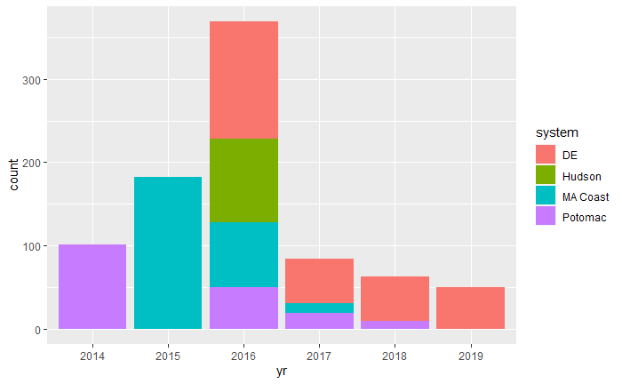

```r
ggplot(data = all_info) +
  geom_bar(aes(x = yr, fill = system))
```

## Age

- A subset of Potomac-tagged fish have not yet been, but are planning to be, aged. There will likely wind up being 1 Hudson River *NA* and 1 Potomac River *NA*.

```r
# Cross-tabulation
addmargins(xtabs(~ age + system, addNA = T, data = all_info))
```

```
      system
age     DE Hudson MA Coast Potomac Sum
  3      0      0       10       5  15
  4      8      0       41      10  59
  5     19      0       56       7  82
  6     22      4       38      26  90
  7     30     10       33      38 111
  8     23     15       23      21  82
  9     23     23       21      14  81
  10    39     20        9      16  84
  11    23     19        8       9  59
  12    19      4        8       2  33
  13    21      4        5       3  33
  14    14      0        1       0  15
  15     7      0        0       0   7
  16     3      0        0       0   3
  17     1      0        0       0   1
  18     2      0        0       0   2
  19     1      0        0       0   1
  <NA>  43      1       19      28  91
  Sum  298    100      272     179 849
```

```r
# Range of ages
all_info[, .(min = min(age, na.rm = T),
             median = median(age, na.rm = T),
             max = max(age, na.rm = T)),
         by = system]
```

| system | min | median | max |
| --- | --- | --- | --- |
| DE | 4 | 10 | 19 |
| MA Coast | 3 | 6 | 14 |
| Potomac | 3 | 7 | 13 |
| Hudson | 6 | 9 | 13 |

- Delaware fish are oldest, followed by Hudson, then Potomac, then Massachusetts.

```r
TukeyHSD(aov(age ~ system, data = all_info))
```

```
  Tukey multiple comparisons of means
    95% family-wise confidence level

Fit: aov(formula = age ~ system, data = all_info)

$system
                       diff        lwr        upr     p adj
Hudson-DE        -0.1158645 -0.8981335  0.6664044 0.9811159
MA Coast-DE      -2.9524917 -3.5386888 -2.3662946 0.0000000
Potomac-DE       -2.0396052 -2.7179440 -1.3612665 0.0000000
MA Coast-Hudson  -2.8366271 -3.6197603 -2.0534940 0.0000000
Potomac-Hudson   -1.9237407 -2.7780322 -1.0694492 0.0000001
Potomac-MA Coast  0.9128864  0.2335512  1.5922216 0.0031946
```

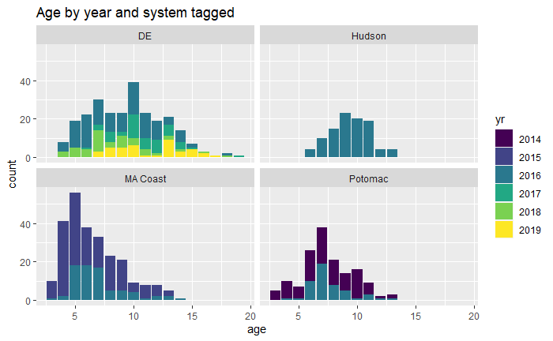

```r
ggplot(data = all_info[!is.na(age)]) +
  geom_bar(aes(x = age, fill = yr)) +
  scale_fill_viridis_d() +
  facet_wrap(~ system) +
  labs(title = 'Age by year and system tagged')
```

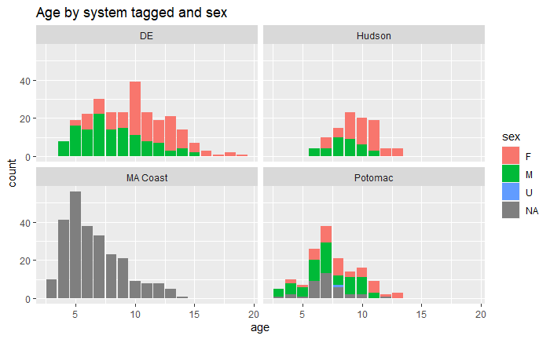

```r
ggplot(data = all_info[!is.na(age)]) +
  geom_bar(aes(x = age, fill = sex)) +
  facet_wrap(~ system) +
  labs(title = 'Age by system tagged and sex')
```

## Sexes

Fish collected off the Massachusetts coast and 21% of Potomac fish were not sexed. “*NA*” means that sex was not recorded, while “*U*” means that the sex was not able to be determined.

```r
addmargins(xtabs(~ sex + system, addNA = T, data = all_info))
```

```
      system
sex     DE Hudson MA Coast Potomac Sum
  F    149     64        0      64 277
  M    149     36        0      77 262
  U      0      0        0       1   1
  <NA>   0      0      272      37 309
  Sum  298    100      272     179 849
```

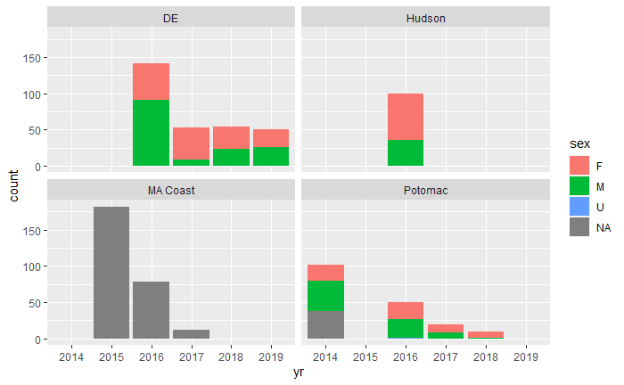

```r
ggplot(data = all_info) +
  geom_bar(aes(x = yr, fill = sex)) +
  facet_wrap(~ system)
```

## Lengths

All fish collected have total lengths, while only Hudson fish have fork lengths. Seems TL is the way to go here.

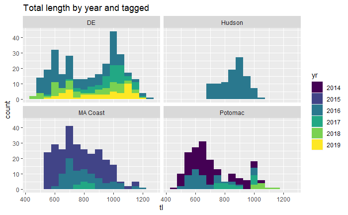

```r
ggplot(data = all_info) +
  geom_histogram(aes(x = tl, fill = yr), binwidth = 50) +
  scale_fill_viridis_d() +
  facet_wrap(~ system) +
  labs(title = 'Total length by year and tagged')
```

- Potomac and MA coast fish skew smaller, Hudson skews larger, and DE is bimodal (related in part to sex, see below)

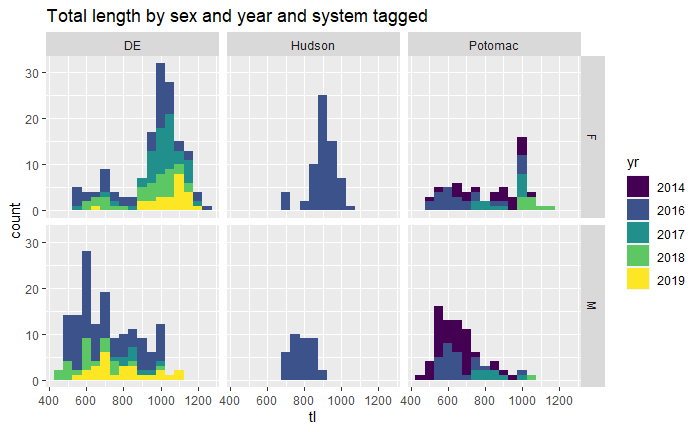

```r
ggplot(data = all_info[!is.na(sex) & sex != 'U']) +
  geom_histogram(aes(x = tl, fill = yr), binwidth = 50) +
  scale_fill_viridis_d() +
  facet_grid(sex ~ system) +
  labs(title = 'Total length by sex and year and system tagged')
```

## Weights

Only Potomac and Hudson fish have recorded weights, with Potomac fish skewing much lighter.

```r
all_info[!is.na(wgt), .N, by = system]
```

| system | N |
| --- | --- |
| Potomac | 178 |
| Hudson | 97 |

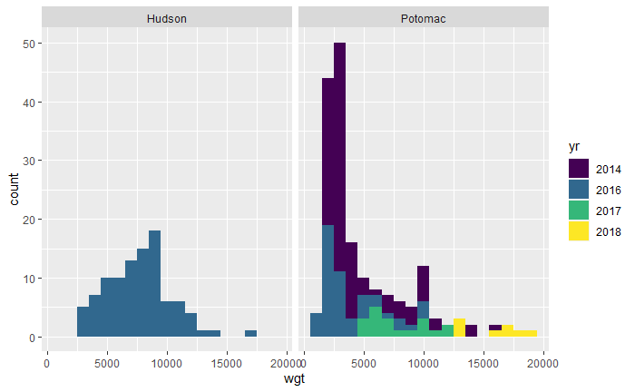

```r
ggplot(data = all_info[!is.na(wgt)]) +
  geom_histogram(aes(x = wgt, fill = yr), binwidth = 1000) +
  scale_fill_viridis_d() +
  facet_wrap(~ system)
```